# Lista avaliativa: IC e TH

Probabilidade e Estatística – 2021.2

fnaufel

17/01/2022 (v. 02/02/2022)

**GABARITO**

# Instruções

- Veja na tabela abaixo o número da questão que foi sorteada para você. Se seu número de matrícula não estiver na tabela, entre em contato comigo pelo Telegram.

  | matricula | questao |
  | --- | --- |
  | 119060007 | 1 |
  | 119060025 | 3 |
  | 119060038 | 8 |
  | 119060043 | 9 |
  | 120060010 | 4 |
  | 120060014 | 6 |
  | 120060029 | 7 |
  | 120060034 | 10 |
  | 216060055 | 5 |
  | 219060053 | 2 |

- Clique o botão `Code`, no início desta página, para baixar o arquivo Rmd deste documento.
- Certifique-se de que o pacote `fnaufelRmd` está instalado. Use os comandos

  ```r
  install.packages("devtools")
  devtools::install_github("fnaufel/fnaufelRmd")
  ```

- Edite o arquivo Rmd para resolver a sua questão.
- Cada item que pede para você construir um intervalo de confiança ou para você fazer um teste de hipóteses deve ser resolvido de duas maneiras (exceto quando houver instrução dizendo o contrário):
  1. Fazendo os cálculos passo a passo, como nos vídeos do curso, e
  2. Usando as funções prontas do R para IC e testes de hipótese que foram usadas nos vídeos do curso.
- Escreva o máximo possível sobre o seu raciocínio. Justifique suas respostas.
- Teste suas respostas. Tudo deve estar executando sem erros.
- Envie no Moodle:
  1. O arquivo Rmd com as suas resoluções e
  2. Um vídeo de até $5$ minutos explicando as suas resoluções.
- Bom trabalho.

# 1 Fumantes

1. Uma amostra aleatória de $86$ pessoas inclui $41$ fumantes.
   1. Construa um intervalo de confiança de $95\%$ para o percentual de fumantes na população de onde foi coletada a amostra.

### Condições

      - A distribuição da população é normal e $n \geq 10$?

        Não sabemos se a distribuição da população é normal.
      - Caso a distribuição da população não seja conhecida, $n \geq 30$?

        Sim.
      - A amostra é aleatória, representativa da população?

        Supomos que sim.
      - Os valores da amostra são independentes entre si?

        Supomos que sim.
      - O tamanho da amostra é menos do que $10\%$ da população?

        Sim.
      - Há pelo menos 10 fracassos e pelo menos 10 sucessos na amostra?

        Sim.

### Passo a passo

      ```r
      n <- 86
      sucessos <- 41
      nivel_confianca <- .95

      pchapeu <- sucessos / n
      cat('pchapeu =', pchapeu)
      ## pchapeu = 0,4767442

      erro_padrao <- sqrt(pchapeu * (1 - pchapeu) / n)
      cat('\nEP =', erro_padrao)
      ```

      ```
      ##
      ## EP = 0,05385804
      ```

      ```r
      valor_critico <- -qnorm((1 - nivel_confianca)/2)
      cat('\nValor crítico =', valor_critico)
      ```

      ```
      ##
      ## Valor crítico = 1,959964
      ```

      ```r
      margem_erro <- erro_padrao * valor_critico
      cat('\nME =', margem_erro)
      ```

      ```
      ##
      ## ME = 0,1055598
      ```

      ```r
      intervalo <- pchapeu + c(-1, 1) * margem_erro
      cat('\nIC = [', intervalo[1], ';', intervalo[2], ']')
      ```

      ```
      ##
      ## IC = [ 0,3711844 ; 0,582304 ]
      ```

      Graficamente, segundo esta amostra, a distribuição amostral de $\hat p$ é a normal abaixo, com média $0{,}477$ e desvio padrão $0{,}054$. A área preenchida corresponde a $95\%$ de probabilidade:

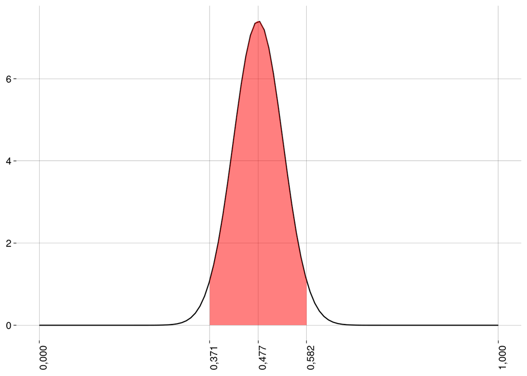

### Usando a função `binom.confint()`

      ```r
      library(binom)
      n <- 86
      sucessos <- 41
      binom.confint(
        sucessos,
        n,
        method = 'asymptotic'
      )
      ```

      |  | method | x | n | mean | lower | upper |
      | --- | --- | --- | --- | --- | --- | --- |
      | 1 | asymptotic | 41 | 86 | 0,4767442 | 0,3711844 | 0,582304 |

   2. Faça um teste de hipóteses para avaliar a afirmação de que o percentual de fumantes na população é diferente de $50\%$. Use $\alpha = 0{,}05$.

### Condições

      Já foram verificadas no item anterior.

### Hipóteses

      $$H_0 : p = 0{,}5$$

      $$H_A : p \neq 0{,}5$$

### Passo a passo

      ```r
      n <- 86
      sucessos <- 41

      # Valor de p na hipótese nula
      pzero <- .5

      # Supondo a hipótese nula
      erro_padrao <- sqrt(pzero * (1 - pzero) / n)
      cat('\nEP =', erro_padrao)
      ```

      ```
      ##
      ## EP = 0,05391639
      ```

      ```r
      pchapeu <- sucessos / n
      cat('\npchapeu =', pchapeu)
      ```

      ```
      ##
      ## pchapeu = 0,4767442
      ```

      ```r
      # Valor p
      valor_p <- 2 * pnorm(
        pchapeu,
        mean = pzero,
        sd = erro_padrao
      )
      cat('\nValor p =', valor_p)
      ```

      ```
      ##
      ## Valor p = 0,6662276
      ```

      Graficamente, o valor $p$ corresponde à área em vermelho abaixo da seguinte distribuição normal, com média $0{,}500$ e desvio padrão $\approx 0{,}054$:

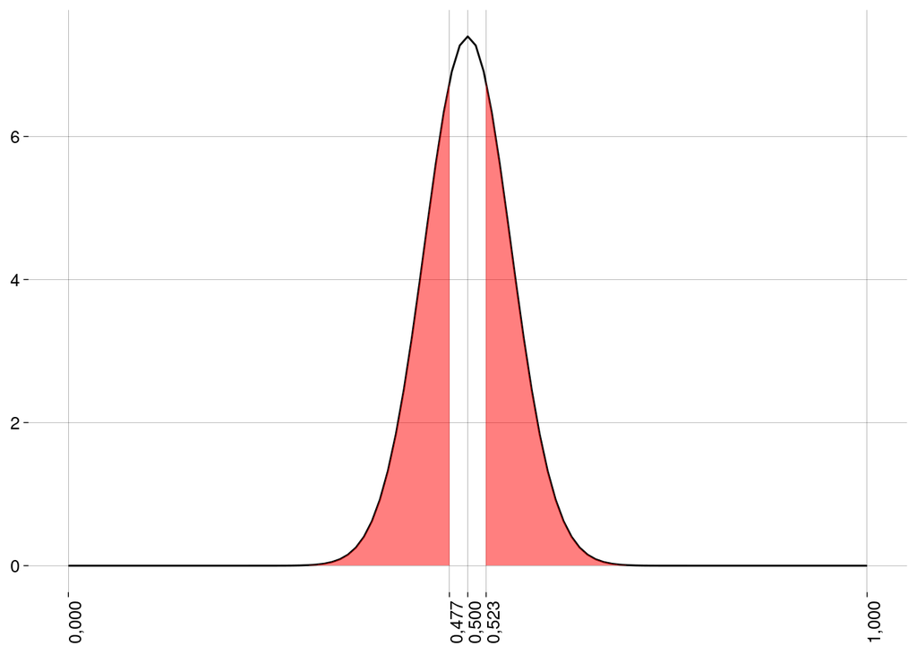

      Note que esta é a distribuição amostral de $\hat p$ supondo que $H_0$ é verdadeira; sua média é $0{,}5$, diferente da distribuição amostral de $\hat p$ baseada na amostra que temos, desenhada acima, cuja média era $0{,}477$.

      Como o valor $p$ $(\approx 0{,}666)$ é muito maior do que $\alpha$ ($0{,}05$), não temos evidência para rejeitar $H_0$.

### Usando a função `prop.test()`

      ```r
      n <- 86
      sucessos <- 41

      prop.test(sucessos, n, p = .5, correct = FALSE)
      ```

      ```
      ##
      ##    1-sample proportions test without continuity correction
      ##
      ## data:  sucessos out of n, null probability 0.5
      ## X-squared = 0,18605, df = 1, p-value = 0,6662
      ## alternative hypothesis: true p is not equal to 0,5
      ## 95 percent confidence interval:
      ##  0,3744554 0,5810217
      ## sample estimates:
      ##         p
      ## 0,4767442
      ```

# 2 Graduação em $4$ anos

1. Qual o tamanho mínimo da amostra necessária para estimar, com um nível de confiança de $95\%$ e uma margem de erro de $0{,}05$ ($5$ pontos percentuais), a proporção de alunos universitários que completam a graduação em $4$ anos ou menos? Nada mais é sabido sobre a população.

   Explique por que você escolheu o valor de $\hat p$ que você escolheu.

   Quando construímos um intervalo de confiança com nível de confiança de $95\%$, a margem de erro é calculada como

   $$\text{ME} = z^\star \cdot \sqrt{\frac{\hat p (1 - \hat p)}{n}}$$

   onde $z^\star = {}$ `-qnorm((1 - .95)/2)` ${} \approx 1{,}96$.

   Se isolarmos $n$, chegamos a

   $$n = \hat p (1-\hat p) \left(\frac{z^\star}{\text{ME}}\right)^2$$

   Não sabemos o valor de $\hat p$. Vamos pensar no maior $n$ possível, que corresponde a $\hat p = 0{,}5$. Então,

   $$n = \hat p (1-\hat p) \left(\frac{z^\star}{\text{ME}}\right)^2
   = 0{,}5 \cdot 0{,}5 \cdot \left( \frac{1{,}96}{0{,}05} \right)^2
   \approx 385$$

   Ou seja, na pior das hipóteses, vamos precisar de uma amostra de $385$ ou mais pessoas.
2. Em uma amostra de $400$ alunos universitários, $150$ completaram a graduação em $4$ anos ou menos. Teste a afirmação de que, na população, menos de $40\%$ dos alunos universitários completam a graduação neste tempo.

### Condições

   - A distribuição da população é normal e $n \geq 10$?

     Não sabemos se a distribuição da população é normal.
   - Caso a distribuição da população não seja conhecida, $n \geq 30$?

     Sim.
   - A amostra é aleatória, representativa da população?

     Supomos que sim.
   - Os valores da amostra são independentes entre si?

     Supomos que sim.
   - O tamanho da amostra é menos do que $10\%$ da população?

     Sim.
   - Há pelo menos 10 fracassos e pelo menos 10 sucessos na amostra?

     Sim.

### Hipóteses

   $$H_0 : p \geq 0{,}4$$

   $$H_A : p < 0{,}4$$

### Passo a passo

   ```r
   n <- 400
   sucessos <- 150

   # Valor de p na hipótese nula
   pzero <- .4

   # Supondo a hipótese nula
   erro_padrao <- sqrt(pzero * (1 - pzero) / n)
   cat('\nEP =', erro_padrao)
   ```

   ```
   ##
   ## EP = 0,0244949
   ```

   ```r
   pchapeu <- sucessos / n
   cat('\npchapeu =', pchapeu)
   ```

   ```
   ##
   ## pchapeu = 0,375
   ```

   ```r
   # Valor p
   valor_p <- pnorm(
     pchapeu,
     mean = pzero,
     sd = erro_padrao
   )
   cat('\nValor p =', valor_p)
   ```

   ```
   ##
   ## Valor p = 0,1537171
   ```

   Graficamente, o valor $p$ corresponde à área em vermelho abaixo da seguinte distribuição normal, com média $0{,}400$ e desvio padrão $\approx 0{,}024$:

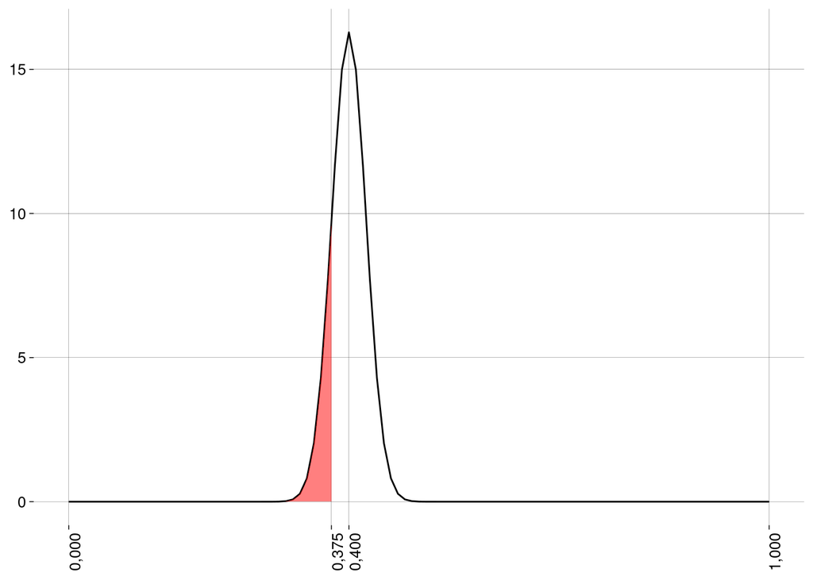

   Como o valor $p$ $(\approx 0{,}154)$ é maior do que $\alpha$ ($0{,}05$), não temos evidência para rejeitar $H_0$.

   Como a hipótese alternativa é $H_A : p < 0{,}4$, o teste é unilateral.

### Usando a função `prop.test()`

   ```r
   n <- 400
   sucessos <- 150

   prop.test(sucessos, n, p = .4, alternative = 'less', correct = FALSE)
   ```

   ```
   ##
   ##   1-sample proportions test without continuity correction
   ##
   ## data:  sucessos out of n, null probability 0.4
   ## X-squared = 1,0417, df = 1, p-value = 0,1537
   ## alternative hypothesis: true p is less than 0,4
   ## 95 percent confidence interval:
   ##  0,0000000 0,4155303
   ## sample estimates:
   ##     p
   ## 0,375
   ```

# 3 Estimativa do tamanho de uma multidão[^1]

Observe a foto abaixo, que mostra parte de uma multidão. A quantidade de pessoas em cada setor quadrado foi estimada por um algoritmo.

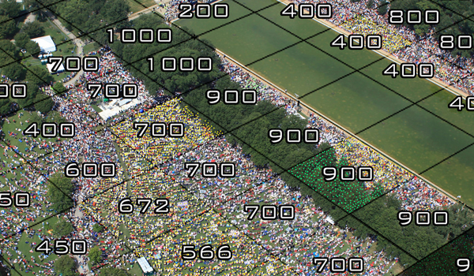

Os valores obtidos para os setores da foto foram

```r
setores <- c(
  200, 400, 800, 1000, 400, 800, 700, 1000, 400, 200, 700, 900, 400, 400, 700, 900,
  600, 700, 900, 650, 672, 700, 900, 450, 566, 700, 900
)
```

1. Construa um intervalo de confiança de $95\%$ para a quantidade média de pessoas por setor na multidão inteira (inclusive as partes que não aparecem na foto).

   A população consiste de todas as quantidades de pessoas por setor na multidão inteira.

   O vetor `setores` é uma amostra.

   Como não sabemos o desvio padrão da população, vamos usar o teste $t$ para estimar a média de pessoas por setor.

### Condições

   - A amostra é aleatória, representativa da população?

     Supomos que sim.
   - Os valores da amostra são independentes entre si?

     Supomos que sim.
   - A amostra vem de uma população aproximadamente normal?

     Podemos fazer um teste de normalidade:

     ```r
     setores %>% shapiro.test()
     ```

     ```
     ##
     ##    Shapiro-Wilk normality test
     ##
     ## data:  .
     ## W = 0,93376, p-value = 0,08547
     ```

     O valor $p$ acima de $0{,}05$ é evidência de que os dados seguem uma distribuição normal.

     Podemos fazer um histograma:

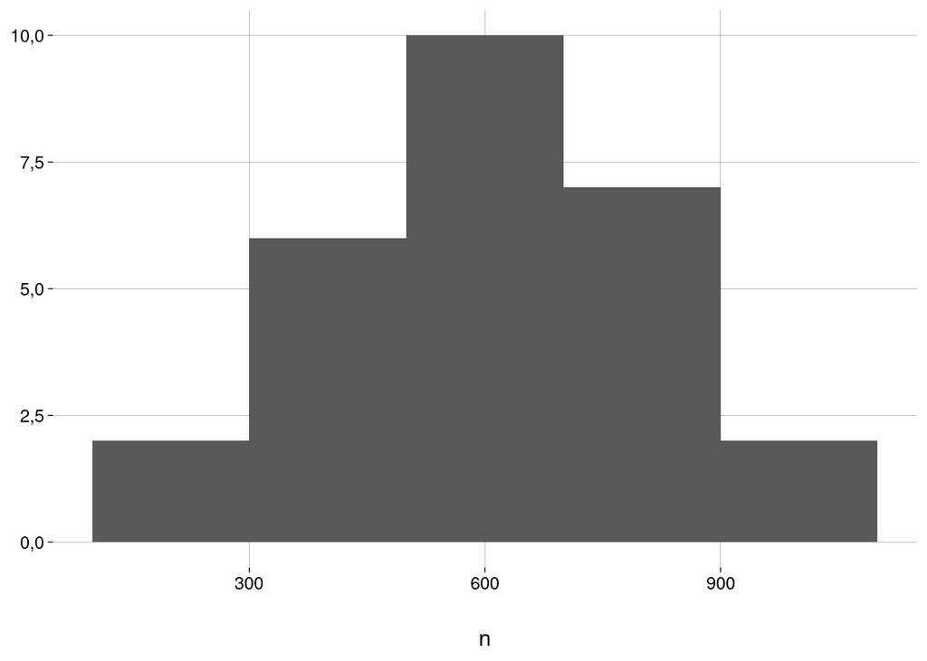

     ```r
     tibble(n = setores) %>%
       ggplot(aes(n)) +
         geom_histogram(bins = 5) +
         labs(y = NULL)
     ```

     A forma do histograma é aproximadamente normal.

### Passo a passo

   ```r
   n = length(setores)
   cat('n =', n)
   ## n = 27

   xbarra <- mean(setores)
   cat('\nMédia amostral =', xbarra)
   ```

   ```
   ##
   ## Média amostral = 653,2593
   ```

   ```r
   s <- sd(setores)
   cat('\nDesvio padrão amostral =', s)
   ```

   ```
   ##
   ## Desvio padrão amostral = 230,7807
   ```

   ```r
   erro_padrao <- s / sqrt(n)
   cat('\nEP =', erro_padrao)
   ```

   ```
   ##
   ## EP = 44,41377
   ```

   ```r
   gl <- n - 1
   cat('\nGraus de liberdade = ', gl)
   ```

   ```
   ##
   ## Graus de liberdade =  26
   ```

   ```r
   nivel_confianca <- .95
   valor_critico <- -qt((1 - nivel_confianca)/2, df = gl)
   cat('\nValor crítico =', valor_critico)
   ```

   ```
   ##
   ## Valor crítico = 2,055529
   ```

   ```r
   margem_erro <- erro_padrao * valor_critico
   cat('\nME =', margem_erro)
   ```

   ```
   ##
   ## ME = 91,29381
   ```

   ```r
   intervalo <- xbarra + c(-1, 1) * margem_erro
   cat('\nIC = [', intervalo[1], ';', intervalo[2], ']')
   ```

   ```
   ##
   ## IC = [ 561,9654 ; 744,5531 ]
   ```

   Graficamente, o intervalo de confiança corresponde à área em vermelho abaixo da seguinte distribuição $t$, com $26$ graus de liberdade:

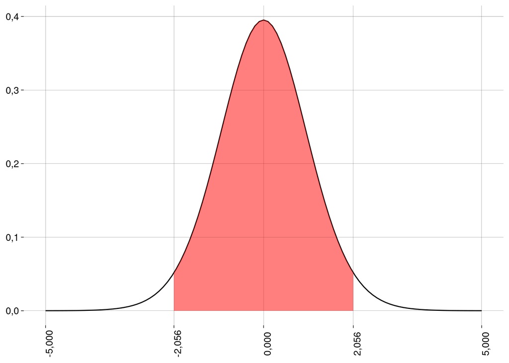

   Observe que esta distribuição $t$ corresponde à variável padronizada

   $$\frac{x - \bar x}{s/\sqrt{n}}$$

   Trabalhamos com esta variável padronizada porque a distribuição $t$ sempre tem média zero.

   Aqui, cada valor no eixo $x$ corresponde ao número de desvios padrão acima ou abaixo da média.

   De fato, o limite inferior da área preenchida corresponde a

   ```r
   (intervalo[1] - xbarra) / erro_padrao
   ```

   ```
   ## [1] -2,055529
   ```

   e o limite superior da área preenchida corresponde a

   ```r
   (intervalo[2] - xbarra) / erro_padrao
   ```

   ```
   ## [1] 2,055529
   ```

### Usando a função `t.test()`

   ```r
   t.test(x = setores)
   ```

   ```
   ##
   ##  One Sample t-test
   ##
   ## data:  setores
   ## t = 14,708, df = 26, p-value = 0,00000000000004076
   ## alternative hypothesis: true mean is not equal to 0
   ## 95 percent confidence interval:
   ##  561,9654 744,5531
   ## sample estimates:
   ## mean of x
   ##  653,2593
   ```

2. Usando o resultado do item anterior e considerando que a multidão inteira cobre $50$ setores, construa um intervalo de confiança para o total de pessoas na multidão.

   Basta multiplicar os valores do intervalo de confiança por $50$:

   ```r
   intervalo * 50
   ```

   ```
   ## [1] 28098,27 37227,65
   ```

3. Faça um teste de hipóteses para avaliar a afirmação de que a multidão inteira consiste de mais de $35$ mil pessoas. Use $\alpha = 0{,}05$.

   A multidão inteira ter $35$ mil pessoas equivale a

   $$\mu = \frac{35.000}{50} = 700$$

   onde $\mu$ é a média de pessoas por setor.

   Antes de fazer qualquer cálculo, percebemos que o valor $700$ está dentro do intervalo de confiança de $95\%$ para a média de pessoas por setor.

   Isto significa que a hipótese de nulidade não vai ser rejeitada.

### Condições

   Já foram verificadas em um item anterior.

### Hipóteses

   $$H_0 : \mu \leq 700$$

   $$H_A : \mu > 700$$

### Passo a passo

   ```r
   n <- length(setores)
   cat('n =', n)
   ## n = 27

   s <- sd(setores)
   cat('\nDesvio padrão amostral =', s)
   ```

   ```
   ##
   ## Desvio padrão amostral = 230,7807
   ```

   ```r
   xbarra <- mean(setores)
   cat('\nMédia amostral =', xbarra)
   ```

   ```
   ##
   ## Média amostral = 653,2593
   ```

   ```r
   # Valor de μ na hipótese nula
   mizero <- 700

   # Supondo a hipótese nula
   erro_padrao <- s / sqrt(n)
   cat('\nEP =', erro_padrao)
   ```

   ```
   ##
   ## EP = 44,41377
   ```

   ```r
   # Média amostral padronizada (supondo a hipótese nula)
   tzero <- (xbarra - mizero) / erro_padrao
   cat('\ntzero =', tzero)
   ```

   ```
   ##
   ## tzero = -1,052393
   ```

   ```r
   # Graus de liberdade
   gl <- n - 1

   # Valor p
   valor_p <- pt(
     tzero,
     df = gl,
     lower.tail = FALSE
   )
   cat('\nValor p =', valor_p)
   ```

   ```
   ##
   ## Valor p = 0,8488489
   ```

   Como o valor $p$ $(\approx 0{,}849)$ é muito maior do que $\alpha$ ($0{,}05$), não temos evidência para rejeitar $H_0$.

   Graficamente, o valor $p$ corresponde à área em vermelho abaixo da seguinte distribuição $t$, com $26$ graus de liberdade, que corresponde à variável padronizada

   $$\frac{x - \bar x}{s/\sqrt{n}}$$

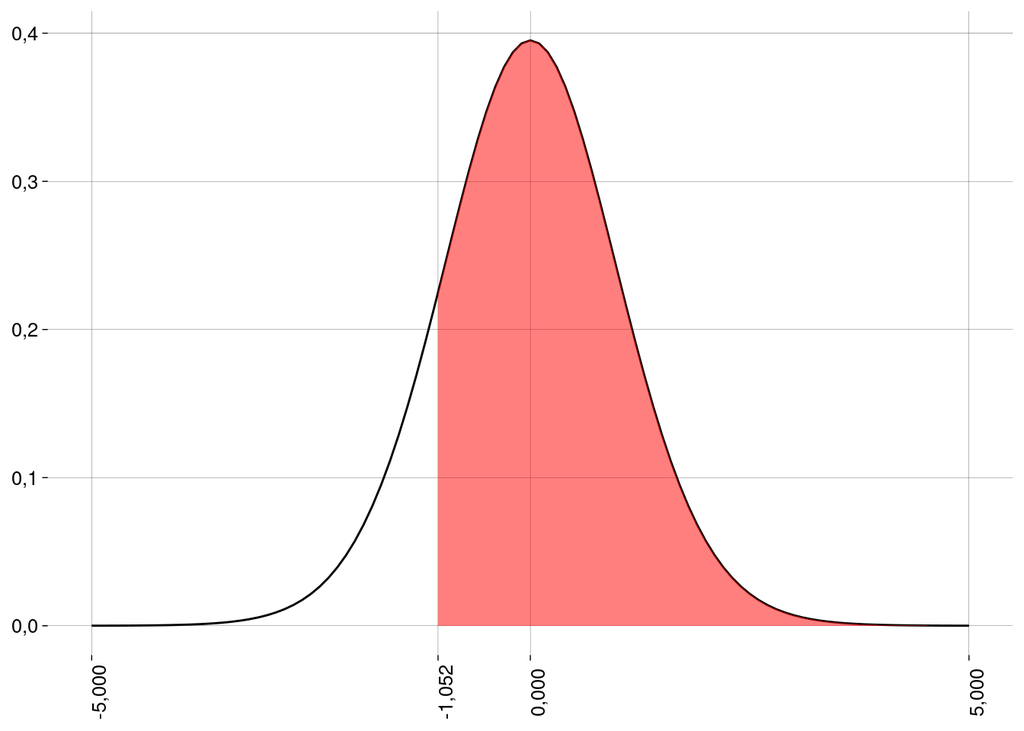

   Como a hipótese alternativa é $H_A : \mu > 700$, o teste é unilateral.

### Usando a função `t.test()`

   ```r
   t.test(x = setores, alternative = 'greater', mu = mizero)
   ```

   ```
   ##
   ##  One Sample t-test
   ##
   ## data:  setores
   ## t = -1,0524, df = 26, p-value = 0,8488
   ## alternative hypothesis: true mean is greater than 700
   ## 95 percent confidence interval:
   ##  577,5063      Inf
   ## sample estimates:
   ## mean of x
   ##  653,2593
   ```

# 4 Pulsação média de mulheres

1. Qual o tamanho mínimo da amostra necessária para estimar, com um nível de confiança de $95\%$ e uma margem de erro de $2$ batimentos por minuto (bpm), a pulsação média de mulheres adultas? De estudos anteriores, podemos usar a informação de que o desvio padrão da população é $\sigma = 12{,}54$ bpm.

   Quando construímos um intervalo de confiança com nível de confiança de $95\%$, a margem de erro é calculada como

   $$\text{ME} = z^\star \cdot \frac{\sigma}{\sqrt{n}}$$

   onde $z^\star = {}$ `-qnorm((1 - .95)/2)` ${} \approx 1{,}96$.

   Se isolarmos $n$, chegamos a

   $$n = \left(\frac{z^\star \cdot \sigma}{\text{ME}}\right)^2$$

   Substituindo os valores que temos:

   $$n = \left(\frac{1{,}96 \cdot 12{,}54}{2}\right)^2
   \approx 152$$

   Vamos precisar de uma amostra de $152$ ou mais pessoas.
2. O vetor `pulsacao` contém os valores das pulsações (em bpm) de diversas mulheres.

   ```r
   pulsacao <- c(
     80, 94, 58, 66, 56, 82, 78, 86, 88, 56, 36, 66, 84, 76, 78, 64, 66,
     78, 60, 64, 84, 82, 70, 74, 86, 90, 88, 90, 90, 94, 68, 90, 82, 80, 74,
     56, 100, 74, 76, 76, 86, 74, 66, 62, 78, 68, 62, 62, 74, 104, 54, 74,
     74, 84, 60, 52, 84, 66, 56, 66, 84, 64, 64, 78, 104, 84, 84, 62, 82, 64,
     78, 76, 86, 72, 82, 82, 66, 58, 62, 80, 58, 82, 76, 70, 88, 44, 58, 64,
     68, 70, 58, 72, 80, 70, 74, 72, 66, 82, 98, 74, 80, 82, 56, 78, 100, 56,
     68, 72, 64, 94, 72, 56, 80, 76, 56, 56, 54, 72, 70, 80, 72, 62, 96, 72,
     60, 98, 72, 80, 84, 68, 86, 72, 80, 64, 82, 80, 62, 74, 96, 72, 96, 64,
     62, 82, 76, 94, 74
   )
   ```

3. Teste a afirmação de que a pulsação média de mulheres adultas é menor do que $70$ bpm. Use $\alpha = 0{,}05$. Use o fato de que $\sigma = 12{,}54$ bpm.

### Condições

   Como temos o valor do desvio padrão da população, podemos usar o teste $z$, cujas condições são:
   - A amostra é aleatória, representativa da população?

     Supomos que sim.
   - Os valores da amostra são independentes entre si?

     Supomos que sim.
   - O tamanho da amostra é menor do que $10\%$ da população?

     A população é o conjunto de todas as mulheres adultas (da cidade? do país?)

     Nossa amostra tem $147$, que é menos do que $10\%$ da população.

### Hipóteses

   $$H_0 : \mu \geq 70$$

   $$H_A : \mu < 70$$

### Passo a passo

   ```r
   n <- length(pulsacao)
   cat('n =', n)
   ## n = 147

   xbarra <- mean(pulsacao)
   cat('\nMédia amostral =', xbarra)
   ```

   ```
   ##
   ## Média amostral = 74,04082
   ```

   ```r
   # Desvio padrão da população (dado)
   sigma <- 12.54

   # Valor de μ na hipótese nula
   mizero <- 70

   erro_padrao <- sigma / sqrt(n)
   cat('\nEP =', erro_padrao)
   ```

   ```
   ##
   ## EP = 1,034282
   ```

   ```r
   # Valor p
   valor_p <- pnorm(
     xbarra,
     mean = mizero,
     sd = erro_padrao
   )
   cat('\nValor p =', valor_p)
   ```

   ```
   ##
   ## Valor p = 0,9999533
   ```

   Como o valor $p$ $(\approx 1{,}000)$ é muito maior do que $\alpha$ ($0{,}05$), não temos evidência para rejeitar $H_0$.

   Além disso, o valor baixo do erro padrão diz que as amostras não variam muito em suas médias; ou seja, esta é uma amostra típica.

   Por isso, é praticamente impossível refutar a hipótese de nulidade com esta amostra.

   Graficamente, o valor $p$ corresponde à área em vermelho abaixo da normal na seguinte figura. Perceba como a área à esquerda do valor de $\bar x = 74{,}041$ é praticamente $100\%$ da área inteira abaixo da curva:

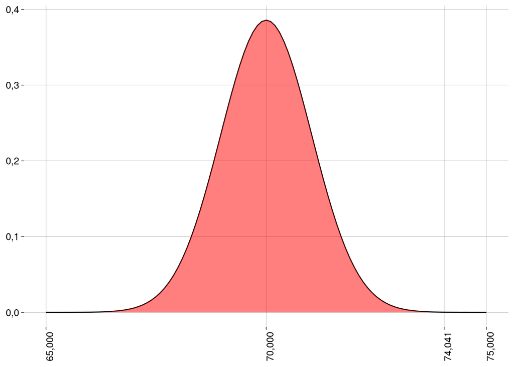

   Como a hipótese alternativa é $H_A : \mu < 70$, o teste é unilateral.

### Usando a função `z.test()`

   ```r
   library(BSDA)
   z.test(
     pulsacao,
     alternative = 'less',
     mu = 70,
     sigma.x = sigma
   )
   ```

   ```
   ##
   ##  One-sample z-Test
   ##
   ## data:  pulsacao
   ## z = 3,9069, p-value = 1
   ## alternative hypothesis: true mean is less than 70
   ## 95 percent confidence interval:
   ##        NA 75,74206
   ## sample estimates:
   ## mean of x
   ##  74,04082
   ```

4. Refaça o item anterior sem usar o fato de que $\sigma = 12{,}54$ bpm.

### Condições

   Como agora não temos o desvio padrão da população, precisamos fazer um teste $t$, cujas condições são:
   - A amostra é aleatória, representativa da população?

     Supomos que sim.
   - Os valores da amostra são independentes entre si?

     Supomos que sim.
   - A amostra vem de uma população aproximadamente normal?

     Podemos fazer um teste de normalidade:

     ```r
     pulsacao %>% shapiro.test()
     ```

     ```
     ##
     ##    Shapiro-Wilk normality test
     ##
     ## data:  .
     ## W = 0,98912, p-value = 0,3102
     ```

     O valor $p$ acima de $0{,}05$ é evidência de que os dados seguem uma distribuição normal.

     Podemos fazer um histograma:

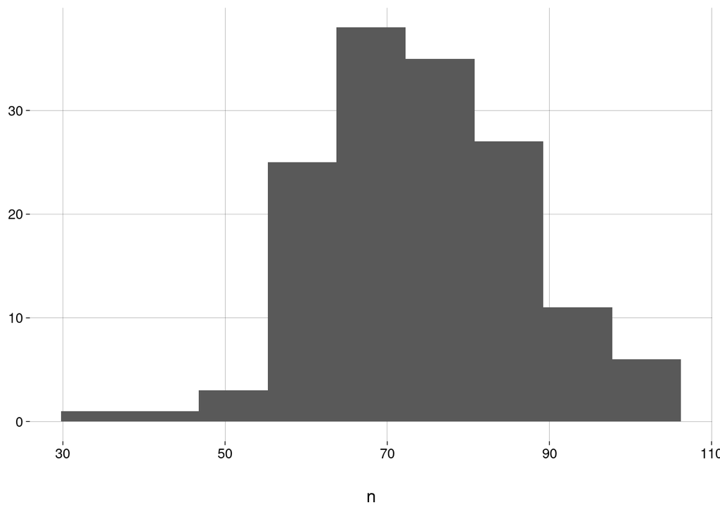

     ```r
     tibble(n = pulsacao) %>%
       ggplot(aes(n)) +
         geom_histogram(bins = 9) +
         labs(y = NULL)
     ```

     A forma do histograma é aproximadamente normal.

### Hipóteses

   $$H_0 : \mu \geq 70$$

   $$H_A : \mu < 70$$

### Passo a passo

   ```r
   n <- length(pulsacao)
   cat('n =', n)
   ## n = 147

   s <- sd(pulsacao)
   cat('\nDesvio padrão amostral =', s)
   ```

   ```
   ##
   ## Desvio padrão amostral = 12,54356
   ```

   ```r
   xbarra <- mean(pulsacao)
   cat('\nMédia amostral =', xbarra)
   ```

   ```
   ##
   ## Média amostral = 74,04082
   ```

   ```r
   # Valor de μ na hipótese nula
   mizero <- 70

   # Supondo a hipótese nula
   erro_padrao <- s / sqrt(n)
   cat('\nEP =', erro_padrao)
   ```

   ```
   ##
   ## EP = 1,034575
   ```

   ```r
   # Média amostral padronizada (supondo a hipótese nula)
   tzero <- (xbarra - mizero) / erro_padrao
   cat('\ntzero =', tzero)
   ```

   ```
   ##
   ## tzero = 3,905774
   ```

   ```r
   # Graus de liberdade
   gl <- n - 1
   cat('\ngl =', gl)
   ```

   ```
   ##
   ## gl = 146
   ```

   ```r
   # Valor p
   valor_p <- pt(
    tzero,
    df = gl
   )
   cat('\nValor p =', valor_p)
   ```

   ```
   ##
   ## Valor p = 0,9999284
   ```

   Como o valor $p$ $(\approx 1{,}000)$ é muito maior do que $\alpha$ ($0{,}05$), não temos evidência para rejeitar $H_0$.

   Graficamente, o valor $p$ corresponde à área em vermelho abaixo da seguinte distribuição $t$, com $146$ graus de liberdade, que corresponde à variável padronizada

   $$\frac{x - \bar x}{s/\sqrt{n}}$$

   Trabalhamos com esta variável padronizada porque a distribuição $t$ sempre tem média zero.

   Aqui, cada valor no eixo $x$ corresponde ao número de desvios padrão acima ou abaixo da média.

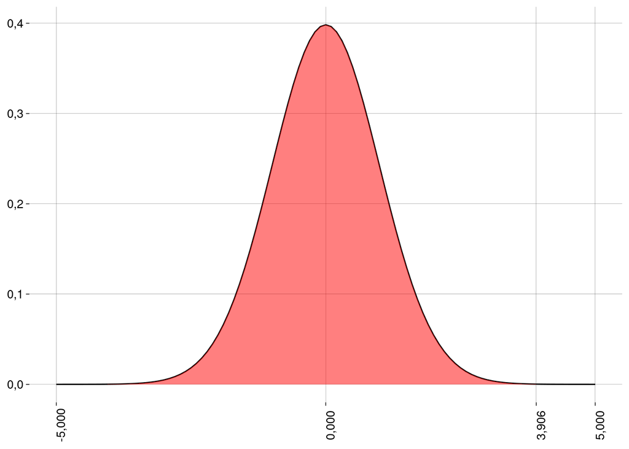

   Como a hipótese alternativa é $H_A : \mu < 70$, o teste é unilateral.

### Usando a função `t.test()`

   ```r
   t.test(x = pulsacao, alternative = 'less', mu = mizero)
   ```

   ```
   ##
   ##  One Sample t-test
   ##
   ## data:  pulsacao
   ## t = 3,9058, df = 146, p-value = 0,9999
   ## alternative hypothesis: true mean is less than 70
   ## 95 percent confidence interval:
   ##      -Inf 75,75341
   ## sample estimates:
   ## mean of x
   ##  74,04082
   ```

5. Compare e comente os resultados.

   Observe que
   - O desvio padrão populacional $\sigma = 12{,}540$ é bem próximo do desvio padrão amostral $s = 12{,}544$.
   - Com $146$ graus de liberdade, a distribuição $t$ é muito próxima da normal padrão:

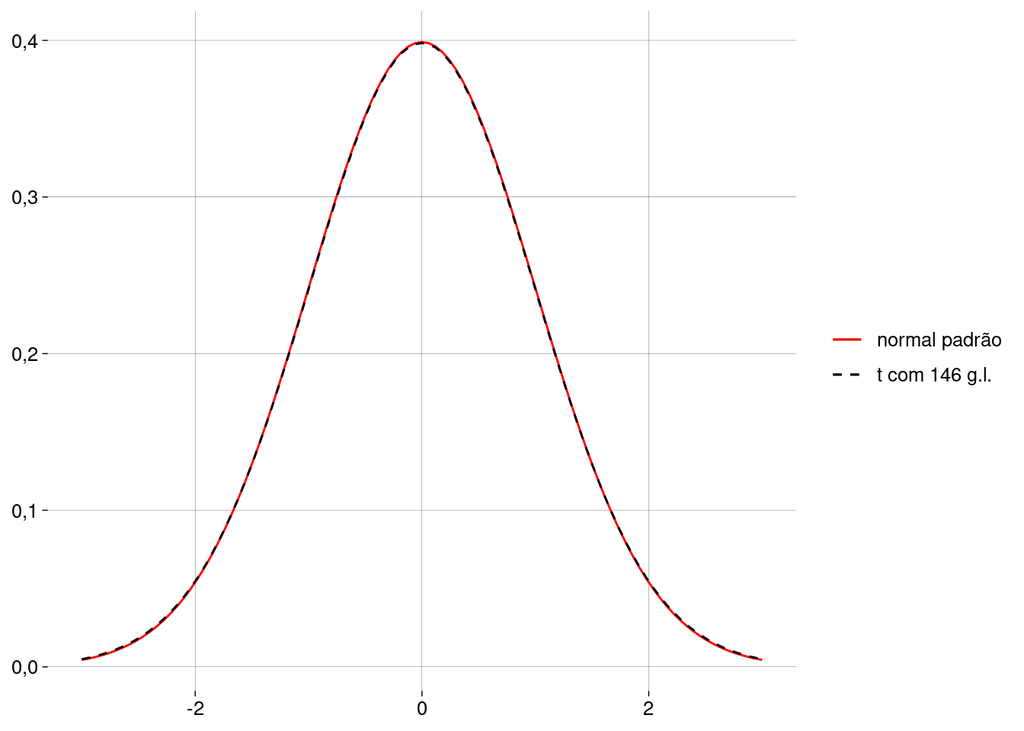

   Estas semelhanças tornam os cálculos dos valores $p$ bem parecidos, tanto no teste $z$ quanto no teste $t$.

# 5 PlayStations com *bootstrapping*

Em uma amostra $A$ de $200$ pessoas, $124$ possuem um PlayStation.

O método de *bootstrapping* consiste em simular muitas amostras — com reposição — a partir dos elementos desta amostra original $A$. A partir destas muitas amostras simuladas, você pode calcular intervalos de confiança como explicado abaixo:

1. Armazene, em uma lista, $10$ mil amostras, cada uma com $200$ pessoas sorteadas com reposição a partir da amostra original $A$ acima (com todas as $200$ pessoas tendo a mesma probabilidade de sorteio).

   Poderíamos criar um vetor com os $200$ elementos da amostra original para passar para a função `sample`:

   ```r
   amostra_original <- rep(c(TRUE, FALSE), c(124, 76))
   ```

   Mas podemos pensar de outro modo: ao escolhermos um elemento da amostra original, a probabilidade de obtermos `TRUE` é igual a $124/200$.

   Ou seja, sortear $200$ pessoas desta amostra com reposição equivale a sortear $200$ valores booleanos, com `TRUE` tendo probabilidade $124/200$ de ser sorteado a cada vez:

   ```r
   n_amostras <- 1e4
   n <- 200
   sucessos <- 124
   p <- sucessos / n

   sortear_amostra_bool <- function(n, p) {

     sample(c(TRUE, FALSE), n, replace = TRUE, prob = c(p, 1 - p))

   }
   ```

   Para construir a lista de $10$ mil amostras:

   ```r
   amostras <- replicate(
     n_amostras,
     sortear_amostra_bool(n, p),
     simplify = FALSE
   )
   ```

   Vamos examinar a lista gerada:

   ```r
   str(amostras)
   ```

   ```
   ## List of 10000
   ##  $ : logi [1:200] FALSE FALSE TRUE TRUE ...
   ##  $ : logi [1:200] TRUE TRUE FALSE TRUE ...
   ##  $ : logi [1:200] TRUE FALSE TRUE TRUE ...
   ##  $ : logi [1:200] FALSE TRUE FALSE TRUE ...
   ##  $ : logi [1:200] TRUE FALSE FALSE TRUE ...
   ##  $ : logi [1:200] TRUE FALSE FALSE FALSE ...
   ##  $ : logi [1:200] TRUE TRUE FALSE TRUE ...
   ##  $ : logi [1:200] TRUE TRUE FALSE FALSE ...
   ##  $ : logi [1:200] FALSE TRUE TRUE TRUE ...
   ##  $ : logi [1:200] TRUE TRUE TRUE FALSE ...
   ##  $ : logi [1:200] FALSE FALSE TRUE FALSE ...
   ##  $ : logi [1:200] TRUE FALSE TRUE TRUE ...
   ##  $ : logi [1:200] TRUE TRUE FALSE TRUE ...
   ##  $ : logi [1:200] FALSE TRUE TRUE TRUE ...
   ```

   [output cut: 86 more lines]

2. Armazene, em um vetor de $10$ mil elementos, as proporções de possuidores de PlayStations nas amostras obtidas no item anterior.

   Lembre-se de que calcular a proporção de valores `TRUE` em um vetor booleano equivale a calcular a média (já que `TRUE` é visto como $1$, e `FALSE` é visto como $0$).

   As funções da família `map` aplicam uma operação (aqui, a média) a cada elemento de um vetor, retornando uma lista. Veja `?purrr::map` para mais detalhes sobre programação funcional em R.

   ```r
   proporcoes <- amostras %>%
     map_dbl(~mean(.))
   ```

   ```r
   str(proporcoes)
   ```

   ```
   ##  num [1:10000] 0,615 0,68 0,59 0,615 0,635 0,61 0,575 0,63 ...
   ```

3. Imprima os valores deste vetor que estão no quantil $0{,}05$ e no quantil $0{,}95$. Estes são os extremos do intervalo de confiança para a proporção de possuidores de PlayStations na população, com $95\%$ de confiança, calculados via *bootstrapping*.

   Uma das vantagens do *bootstrapping* é não precisar de qualquer conhecimento sobre a população — sua distribuição, sua variância etc.

   ```r
   ic_bs <- proporcoes %>%
     quantile(c(.05, .95))

   ic_bs
   ```

   ```
   ##    5%   95%
   ## 0,565 0,675
   ```

4. Use a função `prop.test()` do R para construir um intervalo de confiança para a proporção de possuidores de PlayStations na população, com $95\%$ de confiança — não é necessário fazer os cálculos passo a passo.

   ```r
   ic_teste <- prop.test(sucessos, n, correct = FALSE)$conf.int
   ic_teste
   ```

   ```
   ## [1] 0,5510672 0,6844099
   ## attr(,"conf.level")
   ## [1] 0,95
   ```

5. Compare com o resultado do *bootstrapping*.

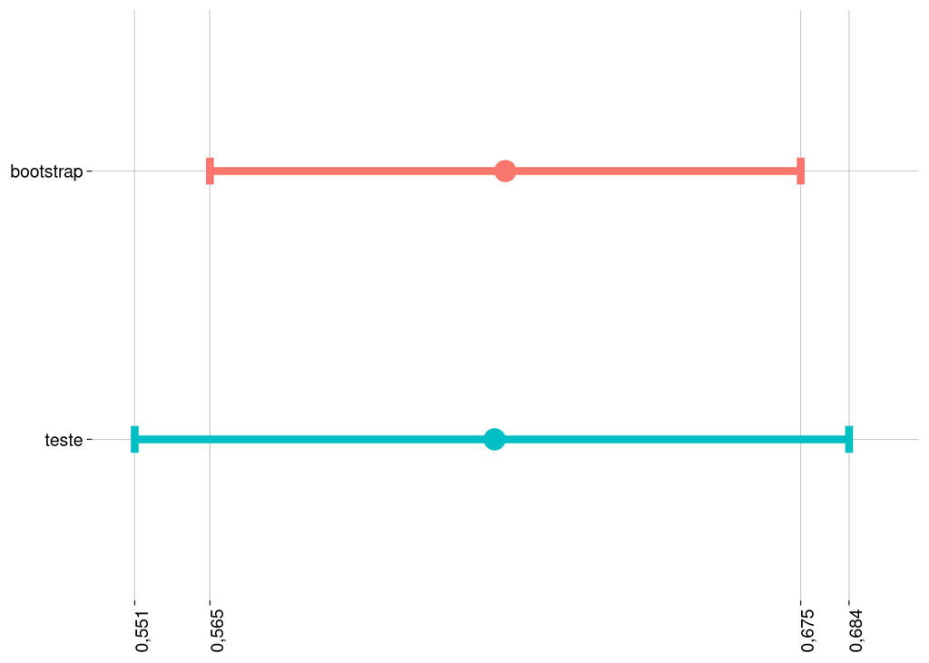

   Os centros dos intervalos são
   - *Bootstrap*: $0{,}620$
   - *Teste*: $0{,}618$

   Os extremos de um intervalo são próximos dos extremos do outro intervalo.

   Como o *bootstrapping* consiste em sortear elementos da amostra original, os resultados podem ser diferentes a cada execução, mas os resultados costumam ser próximos aos dos testes paramétricos — como `prop.test`.

   Se tomarmos uma quantidade maior de amostras — aqui, foram $10$ mil — a precisão melhorará mais ainda. Experimente.

# 6 Telefones celulares com *bootstrapping*

Uma amostra das quantidades de radiação emitidas por telefones celulares consiste dos seguintes valores:

```r
radiacao <- c(38, 55, 86, 91, 99, 103, 145)
```

O método de *bootstrapping* consiste em simular muitas amostras — com reposição — a partir dos elementos desta amostra original. A partir destas muitas amostras simuladas, você pode calcular intervalos de confiança como explicado abaixo:

1. Armazene, em uma lista, $10$ mil amostras, cada uma com $7$ elementos sorteados com reposição a partir do vetor `radiacao` (com todos os elementos tendo a mesma probabilidade de sorteio).

   ```r
   n_amostras <- 1e4
   n <- length(radiacao)
   amostras <- replicate(
     n_amostras,
     sample(radiacao, n, replace = TRUE),
     simplify = FALSE
   )
   ```

   Vamos examinar a lista gerada:

   ```r
   str(amostras)
   ```

   ```
   ## List of 10000
   ##  $ : num [1:7] 91 103 86 99 86 99 55
   ##  $ : num [1:7] 145 55 99 38 86 38 86
   ##  $ : num [1:7] 86 86 99 55 99 145 38
   ##  $ : num [1:7] 103 55 86 38 86 145 38
   ##  $ : num [1:7] 55 145 86 86 99 91 145
   ##  $ : num [1:7] 145 55 103 145 55 145 145
   ##  $ : num [1:7] 86 99 55 99 99 86 99
   ##  $ : num [1:7] 99 55 99 91 86 91 103
   ##  $ : num [1:7] 91 38 99 86 103 99 145
   ##  $ : num [1:7] 86 55 91 38 91 91 86
   ##  $ : num [1:7] 38 145 99 55 103 99 55
   ##  $ : num [1:7] 99 86 145 55 103 99 91
   ##  $ : num [1:7] 38 103 99 86 99 38 145
   ##  $ : num [1:7] 38 55 103 86 86 86 99
   ```

   [output cut: 86 more lines]

2. Armazene, em um vetor de $10$ mil elementos, as médias das amostras obtidas no item anterior.

   As funções da família `map` aplicam uma operação (aqui, a média) a cada elemento de um vetor, retornando uma lista. Veja `?purrr::map` para mais detalhes sobre programação funcional em R.

   ```r
   medias <- amostras %>%
     map_dbl(~mean(.))
   ```

   ```r
   str(medias)
   ```

   ```
   ##  num [1:10000] 88,4 78,1 86,9 78,7 ...
   ```

3. Imprima os valores deste vetor que estão no quantil $0{,}05$ e no quantil $0{,}95$. Estes são os extremos do intervalo de confiança para a radiação média na população, com $95\%$ de confiança, calculados via *bootstrapping*.

   Uma das vantagens do *bootstrapping* é não precisar de qualquer conhecimento sobre a população — sua distribuição, sua variância etc.

   ```r
   ic_bs <- medias %>%
     quantile(c(.05, .95))

   ic_bs
   ```

   ```
   ##        5%       95%
   ##  68,57143 108,57143
   ```

4. Use a função `t.test()` do R para construir um intervalo de confiança para a radiação média, com $95\%$ de confiança — não é necessário fazer os cálculos passo a passo.

   ```r
   ic_teste <- t.test(radiacao)$conf.int
   ic_teste
   ```

   ```
   ## [1]  56,11225 120,17346
   ## attr(,"conf.level")
   ## [1] 0,95
   ```

5. Compare com o resultado do *bootstrapping*.

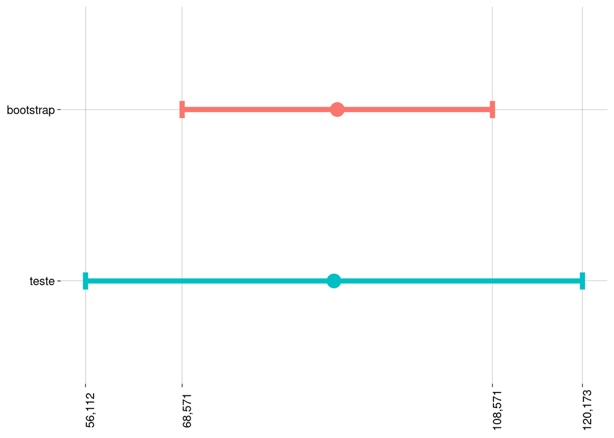

   Os centros dos intervalos são
   - *Bootstrap*: $88{,}571$
   - *Teste*: $88{,}143$

   Os extremos de um intervalo são mais ou menos próximos dos extremos do outro intervalo. Neste exemplo, a amostra original era pequena; se fosse maior, os intervalos seriam mais parecidos.

   Como o *bootstrapping* consiste em sortear elementos da amostra original, os resultados podem ser diferentes a cada execução, mas os resultados costumam ser próximos aos dos testes paramétricos — como `prop.test`.

# 7 Sonhando em cores ou em preto e branco[^2]

Dentre $306$ pessoas com mais de $55$ anos, $68$ disseram que sonham em preto e branco.

Dentre $298$ pessoas com menos de $25$ anos, $13$ disseram que sonham em preto e branco.

1. Construa um intervalo de confiança de $99\%$ para a diferença entre as duas proporções.

### Condições

   - A distribuição da população é normal e $n \geq 10$?

     Não sabemos se a distribuição da população é normal.
   - Caso a distribuição da população não seja conhecida, $n \geq 30$?

     Sim.
   - As amostras são aleatórias, representativas das populações?

     Supomos que sim.
   - Os valores da amostra são independentes entre si?

     Supomos que sim.
   - O tamanho da amostra é menos do que $10\%$ da população?

     Sim.
   - Há pelo menos 10 fracassos e pelo menos 10 sucessos em cada amostra?

     Sim.
   - Os grupos são independentes?

     Supomos que sim (não são parentes nem de outra forma relacionados).

### Passo a passo

   ```r
   n1 <- 306
   sucessos1 <- 68
   pchapeu1 <- sucessos1 / n1
   cat('\npchapeu1 =', pchapeu1)
   ```

   ```
   ##
   ## pchapeu1 = 0,2222222
   ```

   ```r
   n2 <- 298
   sucessos2 <- 13
   pchapeu2 <- sucessos2 / n2
   cat('\npchapeu2 =', pchapeu2)
   ```

   ```
   ##
   ## pchapeu2 = 0,04362416
   ```

   ```r
   dchapeu <- pchapeu1 - pchapeu2
   cat('\ndchapeu =', dchapeu)
   ```

   ```
   ##
   ## dchapeu = 0,1785981
   ```

   ```r
   nivel_confianca <- .99

   erro_padrao <- sqrt(
     (pchapeu1 * (1 - pchapeu1) / n1) +
     (pchapeu2 * (1 - pchapeu2) / n2)
   )
   cat('\nEP =', erro_padrao)
   ```

   ```
   ##
   ## EP = 0,0265488
   ```

   ```r
   valor_critico <- -qnorm((1 - nivel_confianca)/2)
   cat('\nValor crítico =', valor_critico)
   ```

   ```
   ##
   ## Valor crítico = 2,575829
   ```

   ```r
   margem_erro <- erro_padrao * valor_critico
   cat('\nME =', margem_erro)
   ```

   ```
   ##
   ## ME = 0,06838517
   ```

   ```r
   intervalo <- dchapeu + c(-1, 1) * margem_erro
   cat('\nIC = [', intervalo[1], ';', intervalo[2], ']')
   ```

   ```
   ##
   ## IC = [ 0,1102129 ; 0,2469832 ]
   ```

   Graficamente, segundo esta amostra, a distribuição amostral de $\hat d$ (a diferença estimada entre as proporções) é a normal abaixo, com média $0{,}179$ e desvio padrão $0{,}027$. A área preenchida corresponde a $99\%$ de probabilidade:

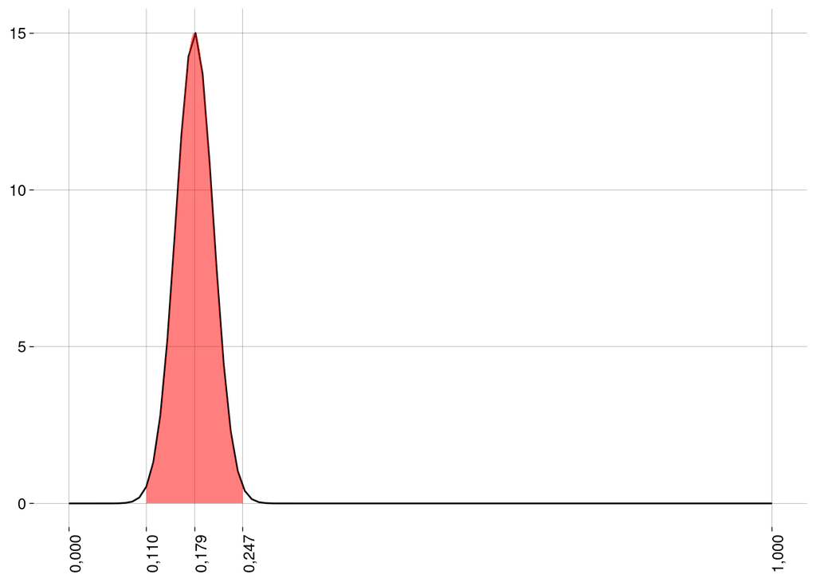

### Usando a função `prop.test`

   ```r
   prop.test(
     matrix(
       c(
         sucessos1, sucessos2,
         n1 - sucessos1, n2 - sucessos2
       ),
       ncol = 2
     ),
     conf.level = .99,
     correct = FALSE
   )
   ```

   ```
   ##
   ##  2-sample test for equality of proportions without continuity correction
   ##
   ## data:  matrix(c(sucessos1, sucessos2, n1 - sucessos1, n2 - sucessos2), ncol = 2)
   ## X-squared = 41,471, df = 1, p-value = 0,0000000001197
   ## alternative hypothesis: two.sided
   ## 99 percent confidence interval:
   ##  0,1102129 0,2469832
   ## sample estimates:
   ##     prop 1     prop 2
   ## 0,22222222 0,04362416
   ```

2. Teste a afirmação de que a proporção de pessoas com mais de $55$ anos que sonham em preto e branco é maior do que a proporção de pessoas com menos de $25$ anos que sonham em preto e branco. Use $\alpha = 0{,}01$.

   Como o intervalo de confiança para a diferença entre as proporções, calculado no item anterior, não inclui o zero, e como $\hat p_1 > \hat p _2$, já sabemos, antes de qualquer cálculo, que a hipótese de nulidade vai ser rejeitada.

   Neste nível de confiança, a amostra é evidência de que a proporção de pessoas com mais de $55$ anos que sonham em preto e branco é maior do que a proporção de pessoas com menos de $25$ anos que sonham em preto e branco.

### Condições

   Já foram verificadas no item anterior.

### Hipóteses

   $$H_0 : p_1 - p_2 \leq 0$$

   $$H_A : p_1 - p_2 > 0$$

### Passo a passo

   ```r
   n1 <- 306
   sucessos1 <- 68
   pchapeu1 <- sucessos1 / n1
   cat('\npchapeu1 =', pchapeu1)
   ```

   ```
   ##
   ## pchapeu1 = 0,2222222
   ```

   ```r
   n2 <- 298
   sucessos2 <- 13
   pchapeu2 <- sucessos2 / n2
   cat('\npchapeu2 =', pchapeu2)
   ```

   ```
   ##
   ## pchapeu2 = 0,04362416
   ```

   ```r
   dchapeu <- pchapeu1 - pchapeu2
   cat('\ndchapeu =', dchapeu)
   ```

   ```
   ##
   ## dchapeu = 0,1785981
   ```

   ```r
   # Valor de d (diferença) na hipótese nula
   dzero <- 0

   # Supondo a hipótese nula
   pbarra <- (sucessos1 + sucessos2) / (n1 + n2)
   erro_padrao <- sqrt(
     (pbarra * (1 - pbarra) / n1) +
     (pbarra * (1 - pbarra) / n2)
   )
   cat('\nEP =', erro_padrao)
   ```

   ```
   ##
   ## EP = 0,02773359
   ```

   ```r
   # Valor p
   valor_p <- pnorm(
     dchapeu,
     mean = dzero,
     sd = erro_padrao,
     lower.tail = FALSE
   )
   cat('\nValor p =', valor_p)
   ```

   ```
   ##
   ## Valor p = 0,00000000005982533
   ```

   Graficamente, o valor $p$ corresponde à área em vermelho (praticamente invisível!) abaixo da seguinte distribuição normal, com média $0$ e desvio padrão $\approx 0{,}028$:

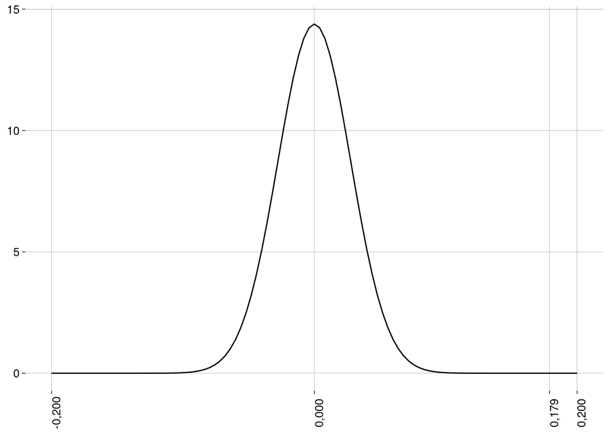

   Como o valor $p$ $(\approx 0{,}00000000005983)$ é muito menor do que $\alpha$ ($0{,}01$), temos evidência para rejeitar $H_0$.

### Usando a função `prop.test()`

   ```r
   prop.test(
     matrix(
       c(
         sucessos1, sucessos2,
         n1 - sucessos1, n2 - sucessos2
       ),
       ncol = 2
     ),
     alternative = 'greater',
     conf.level = .99,
     correct = FALSE
   )
   ```

   ```
   ##
   ##  2-sample test for equality of proportions without continuity correction
   ##
   ## data:  matrix(c(sucessos1, sucessos2, n1 - sucessos1, n2 - sucessos2), ncol = 2)
   ## X-squared = 41,471, df = 1, p-value = 0,00000000005983
   ## alternative hypothesis: greater
   ## 99 percent confidence interval:
   ##  0,1168363 1,0000000
   ## sample estimates:
   ##     prop 1     prop 2
   ## 0,22222222 0,04362416
   ```

# 8 Professores $\times$ professoras[^3]

Professoras mulheres recebem avaliações melhores do que professores homens?

Em uma universidade, as professoras mulheres receberam as seguintes notas dos alunos:

```r
mulheres <- c(
 4.3, 4.3, 4.4, 4.0, 3.4, 4.7, 2.9, 4.0, 4.3, 3.4, 3.4, 3.3
)
```

Na mesma universidade, os professores homens receberam as seguintes notas:

```r
homens <- c(
 4.5, 3.7, 4.2, 3.9, 3.1, 4.0, 3.8, 3.4, 4.5, 3.8, 4.3, 4.4, 4.1, 4.2, 4.0
)
```

Nada é sabido sobre as variâncias das duas populações.

1. Construa um intervalo de confiança de $95\%$ para a diferença entre as médias.

### Condições

   - As amostras são aleatórias, representativas da população?

     Supomos que sim.
   - Os valores das amostras são independentes entre si?

     Supomos que sim.
   - As amostras são menos do que $10\%$ da população?

     Sim.
   - As amostras vêm de populações aproximadamente normais?

     Podemos fazer testes de normalidade:

     ```r
     mulheres %>% shapiro.test()
     ```

     ```
     ##
     ##    Shapiro-Wilk normality test
     ##
     ## data:  .
     ## W = 0,91737, p-value = 0,2648
     ```

     ```r
     homens %>% shapiro.test()
     ```

     ```
     ##
     ##    Shapiro-Wilk normality test
     ##
     ## data:  .
     ## W = 0,94474, p-value = 0,4457
     ```

     Os valores $p$ acima de $0{,}05$ são evidência de que os dados seguem uma distribuição normal.

### Passo a passo

   ```r
   n_1 = length(mulheres)
   cat('n_1 =', n_1)
   ## n_1 = 12

   xbarra_1 <- mean(mulheres)
   cat('\nMédia amostral 1 =', xbarra_1)
   ```

   ```
   ##
   ## Média amostral 1 = 3,866667
   ```

   ```r
   s_1 <- sd(mulheres)
   cat('\nDesvio padrão amostral 1 =', s_1)
   ```

   ```
   ##
   ## Desvio padrão amostral 1 = 0,5630006
   ```

   ```r
   n_2 = length(homens)
   cat('\nn_2 =', n_2)
   ```

   ```
   ##
   ## n_2 = 15
   ```

   ```r
   xbarra_2 <- mean(homens)
   cat('\nMédia amostral 2 =', xbarra_2)
   ```

   ```
   ##
   ## Média amostral 2 = 3,993333
   ```

   ```r
   s_2 <- sd(homens)
   cat('\nDesvio padrão amostral 2 =', s_1)
   ```

   ```
   ##
   ## Desvio padrão amostral 2 = 0,5630006
   ```

   ```r
   d <- xbarra_1 - xbarra_2
   cat('\nDiferença =', d)
   ```

   ```
   ##
   ## Diferença = -0,1266667
   ```

   ```r
   erro_padrao <- sqrt(s_1^2 / n_1 + s_2^2 / n_2)
   cat('\nEP =', erro_padrao)
   ```

   ```
   ##
   ## EP = 0,1919363
   ```

   ```r
   gl <- (s_1^2 / n_1 + s_2^2 / n_2)^2 / (
     (s_1^2 / n_1)^2 / (n_1 - 1) +
     (s_2^2 / n_2)^2 / (n_2 - 1)
   )
   cat('\nGraus de liberdade = ', gl)
   ```

   ```
   ##
   ## Graus de liberdade =  19,06342
   ```

   ```r
   nivel_confianca <- .95
   valor_critico <- -qt((1 - nivel_confianca)/2, df = gl)
   cat('\nValor crítico =', valor_critico)
   ```

   ```
   ##
   ## Valor crítico = 2,092553
   ```

   ```r
   margem_erro <- erro_padrao * valor_critico
   cat('\nME =', margem_erro)
   ```

   ```
   ##
   ## ME = 0,4016368
   ```

   ```r
   intervalo <- d + c(-1, 1) * margem_erro
   cat('\nIC = [', intervalo[1], ';', intervalo[2], ']')
   ```

   ```
   ##
   ## IC = [ -0,5283035 ; 0,2749702 ]
   ```

   Graficamente, o intervalo de confiança corresponde à área em vermelho abaixo da seguinte distribuição $t$, com $19{,}063$ graus de liberdade:

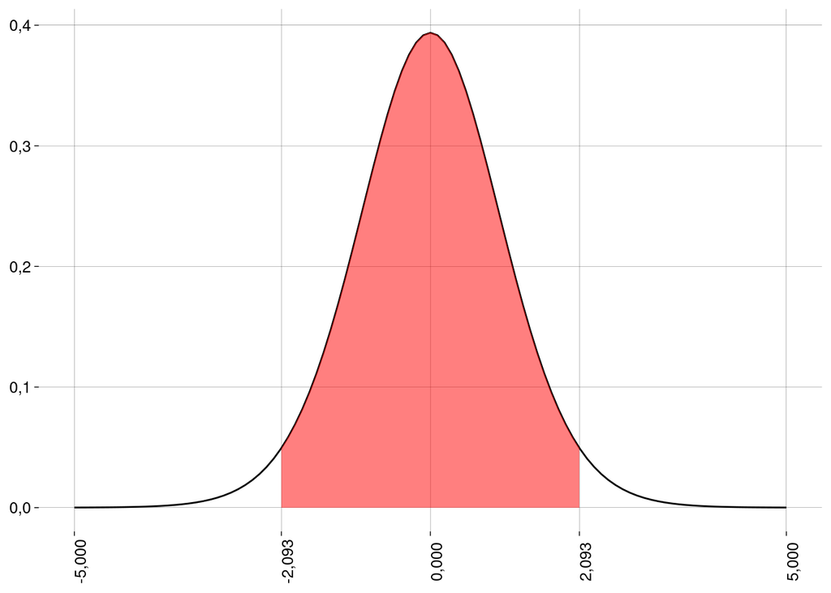

   Observe que esta distribuição $t$ corresponde à variável padronizada

   $$\frac{x - (\bar x_1 - \bar x_2)}{\sqrt{s_1^2 / n_1 + s_2^2 / n_2}}$$

   Trabalhamos com esta variável padronizada porque a distribuição $t$ sempre tem média zero.

   Aqui, cada valor no eixo $x$ corresponde ao número de desvios padrão acima ou abaixo da média.

   De fato, o limite inferior da área preenchida corresponde a

   ```r
   (intervalo[1] - (xbarra_1 - xbarra_2)) / erro_padrao
   ```

   ```
   ## [1] -2,092553
   ```

   e o limite superior da área preenchida corresponde a

   ```r
   (intervalo[2] - (xbarra_1 - xbarra_2)) / erro_padrao
   ```

   ```
   ## [1] 2,092553
   ```

### Usando a função `t.test()`

   ```r
   t.test(
     x = mulheres,
     y = homens
   )
   ```

   ```
   ##
   ##  Welch Two Sample t-test
   ##
   ## data:  mulheres and homens
   ## t = -0,65994, df = 19,063, p-value = 0,5172
   ## alternative hypothesis: true difference in means is not equal to 0
   ## 95 percent confidence interval:
   ##  -0,5283035  0,2749702
   ## sample estimates:
   ## mean of x mean of y
   ##  3,866667  3,993333
   ```

2. Teste a afirmação de que as médias são diferentes. Use $\alpha = 0{,}05$.

### Condições

   Já foram verificadas no item anterior.

### Hipóteses

   $$H_0 : \mu_1 - \mu_2 = 0$$

   $$H_A : \mu_1 - \mu_2 \neq 0$$

### Passo a passo

   ```r
   n_1 = length(mulheres)
   cat('n_1 =', n_1)
   ## n_1 = 12

   xbarra_1 <- mean(mulheres)
   cat('\nMédia amostral 1 =', xbarra_1)
   ```

   ```
   ##
   ## Média amostral 1 = 3,866667
   ```

   ```r
   s_1 <- sd(mulheres)
   cat('\nDesvio padrão amostral 1 =', s_1)
   ```

   ```
   ##
   ## Desvio padrão amostral 1 = 0,5630006
   ```

   ```r
   n_2 = length(homens)
   cat('\nn_2 =', n_2)
   ```

   ```
   ##
   ## n_2 = 15
   ```

   ```r
   xbarra_2 <- mean(homens)
   cat('\nMédia amostral 2 =', xbarra_2)
   ```

   ```
   ##
   ## Média amostral 2 = 3,993333
   ```

   ```r
   s_2 <- sd(homens)
   cat('\nDesvio padrão amostral 2 =', s_1)
   ```

   ```
   ##
   ## Desvio padrão amostral 2 = 0,5630006
   ```

   ```r
   erro_padrao <- sqrt(s_1^2 / n_1 + s_2^2 / n_2)
   cat('\nEP =', erro_padrao)
   ```

   ```
   ##
   ## EP = 0,1919363
   ```

   ```r
   d <- xbarra_1 - xbarra_2
   cat('\nDiferença =', d)
   ```

   ```
   ##
   ## Diferença = -0,1266667
   ```

   ```r
   # Vamos padronizar esta diferença
   tx <- (d - 0) / erro_padrao
   cat('\nDiferença padronizada =', tx)
   ```

   ```
   ##
   ## Diferença padronizada = -0,6599412
   ```

   ```r
   gl <- (s_1^2 / n_1 + s_2^2 / n_2)^2 / (
     (s_1^2 / n_1)^2 / (n_1 - 1) +
     (s_2^2 / n_2)^2 / (n_2 - 1)
   )
   cat('\nGraus de liberdade =', gl)
   ```

   ```
   ##
   ## Graus de liberdade = 19,06342
   ```

   ```r
   valor_p <- 2 * pt(
     tx,
     df = gl
   )
   cat('\nValor p =', valor_p)
   ```

   ```
   ##
   ## Valor p = 0,5171864
   ```

   Como o valor $p$ $(\approx 0{,}517)$ é maior do que $\alpha$ ($0{,}05$), não temos evidência para rejeitar $H_0$.

   Graficamente, o valor $p$ corresponde à área em vermelho abaixo da seguinte distribuição $t$, com $19{,}063$ graus de liberdade, que corresponde à variável padronizada

   $$\frac{x - (\bar x_1 - \bar x_2)}{\sqrt{s_1^2 / n_1 + s_2^2 / n_2}}$$

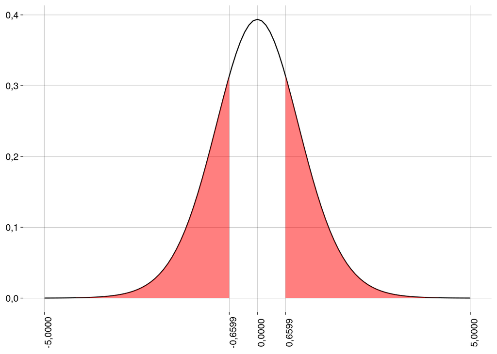

   Como a hipótese alternativa é $H_A : \mu_1 - \mu_2 \neq 0$, o teste é bilateral.

### Usando a função `t.test()`

   ```r
   t.test(
     x = mulheres,
     y = homens
   )
   ```

   ```
   ##
   ##  Welch Two Sample t-test
   ##
   ## data:  mulheres and homens
   ## t = -0,65994, df = 19,063, p-value = 0,5172
   ## alternative hypothesis: true difference in means is not equal to 0
   ## 95 percent confidence interval:
   ##  -0,5283035  0,2749702
   ## sample estimates:
   ## mean of x mean of y
   ##  3,866667  3,993333
   ```

# 9 Mulheres $\times$ maridos[^4]

A tabela abaixo mostra as quantidades de palavras faladas em um dia pelos maridos e mulheres em $8$ casais:

| casal | marido | mulher |
| --- | --- | --- |
| 1 | 15.684 | 24.625 |
| 2 | 26.429 | 13.397 |
| 3 | 1.411 | 18.338 |
| 4 | 7.771 | 17.791 |
| 5 | 18.876 | 12.964 |
| 6 | 15.477 | 16.937 |
| 7 | 14.069 | 16.255 |
| 8 | 25.835 | 18.667 |

1. Construa um intervalo de confiança de $95\%$ para a diferença média entre as quantidades de palavras faladas pelos dois cônjuges de um casal.

### Condições

   - As amostras são aleatórias, representativas da população?

     Supomos que sim.
   - Os pares são independentes entre si?

     Supomos que sim. O comportamento de um casal não afeta o comportamento dos outros.
   - As amostras são menos do que $10\%$ da população?

     Sim.
   - A amostra vem de uma população aproximadamente normal?

     Podemos fazer um teste de normalidade sobre as diferenças:

     ```r
     (df$marido - df$mulher) %>% shapiro.test()
     ```

     ```
     ##
     ##    Shapiro-Wilk normality test
     ##
     ## data:  .
     ## W = 0,97075, p-value = 0,9038
     ```

     O valor $p$ acima de $0{,}05$ é evidência de que os dados seguem uma distribuição normal.

### Passo a passo

   ```r
   n = nrow(df)
   cat('\nn =', n)
   ```

   ```
   ##
   ## n = 8
   ```

   ```r
   dbarra <- mean(df$marido - df$mulher)
   cat('\nMédia amostral das diferenças =', dbarra)
   ```

   ```
   ##
   ## Média amostral das diferenças = -1677,75
   ```

   ```r
   s <- sd(df$marido - df$mulher)
   cat('\nDesvio padrão amostral das diferenças =', s)
   ```

   ```
   ##
   ## Desvio padrão amostral das diferenças = 10052,87
   ```

   ```r
   erro_padrao <- s / sqrt(n)
   cat('\nEP =', erro_padrao)
   ```

   ```
   ##
   ## EP = 3554,227
   ```

   ```r
   gl <- n - 1
   cat('\nGraus de liberdade = ', gl)
   ```

   ```
   ##
   ## Graus de liberdade =  7
   ```

   ```r
   nivel_confianca <- .95
   valor_critico <- -qt((1 - nivel_confianca)/2, df = gl)
   cat('\nValor crítico =', valor_critico)
   ```

   ```
   ##
   ## Valor crítico = 2,364624
   ```

   ```r
   margem_erro <- erro_padrao * valor_critico
   cat('\nME =', margem_erro)
   ```

   ```
   ##
   ## ME = 8404,411
   ```

   ```r
   intervalo <- dbarra + c(-1, 1) * margem_erro
   cat('\nIC = [', intervalo[1], ';', intervalo[2], ']')
   ```

   ```
   ##
   ## IC = [ -10082,16 ; 6726,661 ]
   ```

   Graficamente, o intervalo de confiança corresponde à área em vermelho abaixo da seguinte distribuição $t$, com $7$ graus de liberdade:

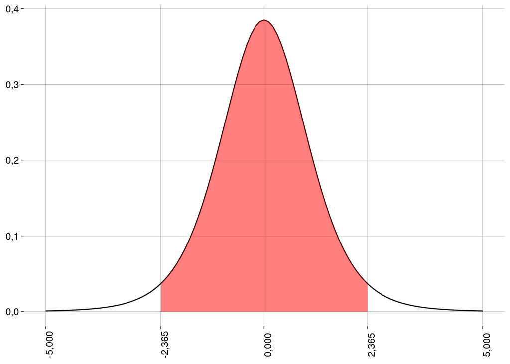

   Observe que esta distribuição $t$ corresponde à variável padronizada

   $$\frac{x - \overline{(x_1 - x_2)}}{s / \sqrt{n}}$$

   Trabalhamos com esta variável padronizada porque a distribuição $t$ sempre tem média zero.

   Aqui, cada valor no eixo $x$ corresponde ao número de desvios padrão acima ou abaixo da média.

   De fato, o limite inferior da área preenchida corresponde a

   ```r
   (intervalo[1] - dbarra) / erro_padrao
   ```

   ```
   ## [1] -2,364624
   ```

   e o limite superior da área preenchida corresponde a

   ```r
   (intervalo[2] - dbarra) / erro_padrao
   ```

   ```
   ## [1] 2,364624
   ```

### Usando a função `t.test()`

   ```r
   t.test(
     x = df$marido,
     y = df$mulher,
     paired = TRUE
   )
   ```

   ```
   ##
   ##  Paired t-test
   ##
   ## data:  df$marido and df$mulher
   ## t = -0,47204, df = 7, p-value = 0,6513
   ## alternative hypothesis: true difference in means is not equal to 0
   ## 95 percent confidence interval:
   ##  -10082,161   6726,661
   ## sample estimates:
   ## mean of the differences
   ##                -1677,75
   ```

2. Teste a afirmação de que, em casais em geral, a mulher fala mais do que o homem. Use $\alpha = 0{,}05$.

   Como o intervalo de confiança para a média das diferenças, calculado no item anterior, inclui o zero, já sabemos, antes de qualquer cálculo, que a hipótese de nulidade não vai ser rejeitada; isto é, a amostra não é evidência de que as mulheres falam mais.

### Condições

   Já foram verificadas no item anterior.

### Hipóteses

   Chamando de $\mu_d$ a média das diferenças
   $$\text{palavras}_\text{marido} -
   \text{palavras}_\text{mulher}$$
   temos

   $$H_0 : \mu_d \geq 0$$

   $$H_A : \mu_d < 0$$

### Passo a passo

   ```r
   n = nrow(df)
   cat('\nn =', n)
   ```

   ```
   ##
   ## n = 8
   ```

   ```r
   dbarra <- mean(df$marido - df$mulher)
   cat('\nMédia amostral das diferenças =', dbarra)
   ```

   ```
   ##
   ## Média amostral das diferenças = -1677,75
   ```

   ```r
   s <- sd(df$marido - df$mulher)
   cat('\nDesvio padrão amostral das diferenças =', s)
   ```

   ```
   ##
   ## Desvio padrão amostral das diferenças = 10052,87
   ```

   ```r
   erro_padrao <- s / sqrt(n)
   cat('\nEP =', erro_padrao)
   ```

   ```
   ##
   ## EP = 3554,227
   ```

   ```r
   gl <- n - 1
   cat('\nGraus de liberdade = ', gl)
   ```

   ```
   ##
   ## Graus de liberdade =  7
   ```

   ```r
   # Vamos padronizar esta diferença
   tx <- (dbarra - 0) / erro_padrao
   cat('\nDiferença padronizada =', tx)
   ```

   ```
   ##
   ## Diferença padronizada = -0,4720436
   ```

   ```r
   valor_p <- pt(
     tx,
     df = gl
   )
   cat('\nValor p =', valor_p)
   ```

   ```
   ##
   ## Valor p = 0,3256283
   ```

   Como o valor $p$ $(\approx 0{,}326)$ é maior do que $\alpha$ ($0{,}05$), não temos evidência para rejeitar $H_0$.

   Graficamente, o valor $p$ corresponde à área em vermelho abaixo da seguinte distribuição $t$, com $7$ graus de liberdade, que corresponde à variável padronizada

   $$\frac{x - \overline{(x_1 - x_2)}}{s / \sqrt{n}}$$

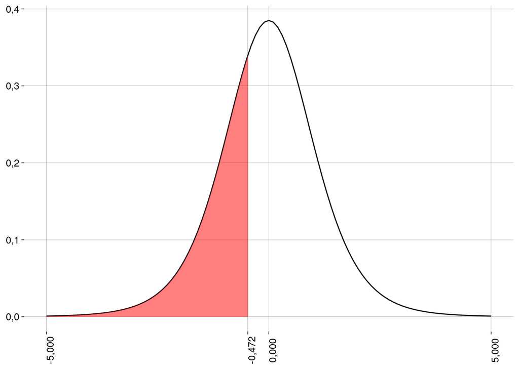

   Como a hipótese alternativa é $H_A : \mu_d < 0$, o teste é unilateral à esquerda.

### Usando a função `t.test()`

   ```r
   t.test(
     x = df$marido,
     y = df$mulher,
     alternative = 'less',
     paired = TRUE
   )
   ```

   ```
   ##
   ##  Paired t-test
   ##
   ## data:  df$marido and df$mulher
   ## t = -0,47204, df = 7, p-value = 0,3256
   ## alternative hypothesis: true difference in means is less than 0
   ## 95 percent confidence interval:
   ##      -Inf 5056,012
   ## sample estimates:
   ## mean of the differences
   ##                -1677,75
   ```

# 10 Temperatura corporal com *bootstrapping*

A tabela abaixo mostra as temperatura corporais (em graus Celsius) de $32$ pessoas, medidas de manhã e de tarde:

| pessoa | manhã | tarde |
| --- | --- | --- |
| 1 | 36,7 | 36,7 |
| 2 | 37,0 | 37,1 |
| 3 | 36,3 | 36,7 |
| 4 | 36,8 | 37,1 |
| 5 | 36,8 | 37,1 |
| 6 | 36,8 | 36,4 |
| 7 | 35,9 | 37,0 |
| 8 | 36,3 | 37,0 |
| 9 | 36,3 | 37,1 |
| 10 | 36,8 | 36,7 |
| 11 | 36,3 | 36,8 |
| 12 | 36,6 | 36,7 |
| 13 | 36,9 | 36,7 |
| 14 | 36,4 | 36,1 |
| 15 | 35,7 | 36,2 |
| 16 | 36,7 | 36,8 |
| 17 | 37,1 | 37,1 |
| 18 | 37,4 | 37,4 |
| 19 | 37,1 | 36,6 |
| 20 | 36,5 | 36,9 |
| 21 | 37,2 | 36,5 |
| 22 | 36,7 | 36,8 |
| 23 | 37,1 | 36,5 |
| 24 | 36,4 | 36,2 |
| 25 | 37,2 | 36,9 |
| 26 | 36,9 | 37,0 |
| 27 | 36,2 | 36,3 |
| 28 | 37,1 | 35,9 |
| 29 | 36,3 | 36,1 |
| 30 | 37,1 | 36,9 |
| 31 | 37,2 | 36,8 |
| 32 | 37,3 | 37,0 |

O método de *bootstrapping* consiste em simular muitas amostras — com reposição — a partir dos elementos desta amostra original. A partir destas muitas amostras simuladas, você pode calcular intervalos de confiança como explicado abaixo:

1. Calcule a diferença entre a temperatura matinal e a temperatura vespertina para cada pessoa, armazenando os resultados em um vetor `diferencas`, com $32$ valores.

   ```r
   diferencas <- df$manhã - df$tarde
   diferencas
   ```

   ```
   ##  [1]  0,0 -0,1 -0,4 -0,3 -0,3  0,4 -1,1 -0,7 -0,8  0,1 -0,5 -0,1  0,2  0,3 -0,5 -0,1
   ## [17]  0,0  0,0  0,5 -0,4  0,7 -0,1  0,6  0,2  0,3 -0,1 -0,1  1,2  0,2  0,2  0,4  0,3
   ```

2. Armazene, em uma lista, $10$ mil amostras, cada uma com $32$ elementos sorteados com reposição a partir do vetor `diferencas` (com todos os elementos tendo a mesma probabilidade de sorteio).

   ```r
   n_amostras <- 1e4
   n <- length(diferencas)
   amostras <- replicate(
     n_amostras,
     sample(diferencas, n, replace = TRUE),
     simplify = FALSE
   )
   ```

   Vamos examinar a lista gerada:

   ```r
   str(amostras)
   ```

   ```
   ## List of 10000
   ##  $ : num [1:32] 0 0,3 -0,3 0,4 ...
   ##  $ : num [1:32] 0,7 0,6 0,2 -0,1 ...
   ##  $ : num [1:32] -0,1 0 0,2 -0,1 ...
   ##  $ : num [1:32] 0 -0,3 0,7 -0,3 ...
   ##  $ : num [1:32] 0,6 0 0 0 ...
   ##  $ : num [1:32] 0,6 -0,4 0 -0,4 ...
   ##  $ : num [1:32] 0,6 1,2 0,2 -0,4 ...
   ##  $ : num [1:32] -1,1 -0,5 0,3 0,3 ...
   ##  $ : num [1:32] 0,3 1,2 0,2 -0,3 ...
   ##  $ : num [1:32] -0,4 -0,1 -0,1 0 ...
   ##  $ : num [1:32] -0,1 -0,1 0,2 0,4 ...
   ##  $ : num [1:32] 0,3 1,2 0,4 0,2 ...
   ##  $ : num [1:32] -0,1 0,4 0,1 -0,5 ...
   ##  $ : num [1:32] -0,1 -0,1 0,2 0 ...
   ```

   [output cut: 86 more lines]

3. Armazene, em um vetor de $10$ mil elementos, as médias das amostras obtidas no item anterior.

   As funções da família `map` aplicam uma operação (aqui, a média) a cada elemento de um vetor, retornando uma lista. Veja `?purrr::map` para mais detalhes sobre programação funcional em R.

   ```r
   medias <- amostras %>%
     map_dbl(~mean(.))
   ```

   ```r
   str(medias)
   ```

   ```
   ##  num [1:10000] 0,03125 -0,00625 0,03125 0,00625 ...
   ```

   Uma das vantagens do *bootstrapping* é não precisar de qualquer conhecimento sobre a população — sua distribuição, sua variância etc.

   ```r
   ic_bs <- medias %>%
     quantile(c(.05, .95))

   ic_bs
   ```

   ```
   ##        5%       95%
   ## -0,134375  0,134375
   ```

5. Use a função `t.test()` do R para construir um intervalo de confiança para a diferença média de temperatura na população, com $95\%$ de confiança — não é necessário fazer os cálculos passo a passo.

   ```r
   ic_teste <- t.test(df$manhã, df$tarde, paired = TRUE)$conf.int
   ic_teste
   ```

   ```
   ## [1] -0,1676132  0,1676132
   ## attr(,"conf.level")
   ## [1] 0,95
   ```

6. Compare com o resultado do *bootstrapping*.

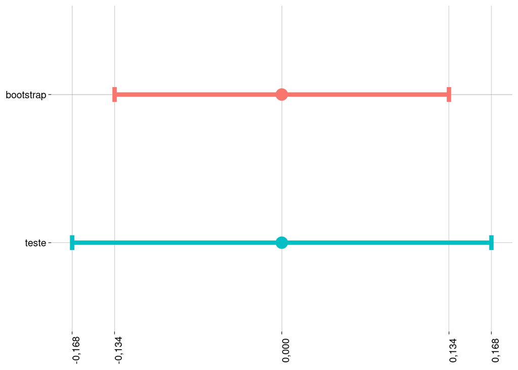

   Os centros dos intervalos são
   - *Bootstrap*: $-0{,}00000000000000077716$
   - *Teste*: $-0{,}00000000000000044409$

   Os extremos de um intervalo são mais ou menos próximos dos extremos do outro intervalo.

   Como o *bootstrapping* consiste em sortear elementos da amostra original, os resultados podem ser diferentes a cada execução, mas os resultados costumam ser próximos aos dos testes paramétricos — como `prop.test`.

   Se tomarmos uma quantidade maior de amostras — aqui, foram $10$ mil — a precisão melhorará mais ainda. Experimente.

# Notas

[^1]: Baseado em https://web.archive.org/web/20101008192855/http://www.lifeslittlemysteries.com/how-is-crowd-size-estimated--1074/
[^2]: Baseado em Murzyn, E. (2008). “Do we only dream in colour? a comparison of reported dream colour in younger and older adults with different experiences of black and white media.” *Consciousness and Cognition*, 17(4), 1228–1237. http://dx.doi.org/10.1016/j.concog.2008.09.002
[^3]: Baseado em Andrew Gelman e Jennifer Hill (2009), “Replication Data for Data Analysis Using Regression Multilevel Hierarchical Models”, http://hdl.handle.net/1902.1/10285
[^4]: Baseado em Mehl, M. R., Vazire, S., Nairán Ramírez-Esparza, Slatcher, R. B., & Pennebaker, J. W. (2007). “Are Women Really More Talkative Than Men?”, *Science*, 317(5834), 82. http://dx.doi.org/10.1126/science.1139940